# chapter3

Anne Paakinaho

9 11 2020

## RStudio exercise 3: Logistic regression

```r
date()
```

```
## [1] "Wed Nov 11 08:51:42 2020"
```

In exercise 3 the idea is to learn about logistic regression. The joined data set used in the analysis exercise combines the two student alcohol consumption data sets. More information about the dataset and the variables can be found here: https://archive.ics.uci.edu/ml/datasets/Student+Performance Here is the paper, where the data was originally used: http://www3.dsi.uminho.pt/pcortez/student.pdf

I will read the joined alcohol consumption into R from the following link: https://github.com/rsund/IODS-project/raw/master/data/alc.csv

```r
alc <- readr::read_csv("https://github.com/rsund/IODS-project/raw/master/data/alc.csv")
dim(alc)
```

```
## [1] 370  51
```

```r
str(alc)
```

```
## tibble [370 x 51] (S3: spec_tbl_df/tbl_df/tbl/data.frame)
##  $ school    : chr [1:370] "GP" "GP" "GP" "GP" ...
##  $ sex       : chr [1:370] "F" "F" "F" "F" ...
##  $ age       : num [1:370] 15 15 15 15 15 15 15 15 15 15 ...
##  $ address   : chr [1:370] "R" "R" "R" "R" ...
##  $ famsize   : chr [1:370] "GT3" "GT3" "GT3" "GT3" ...
##  $ Pstatus   : chr [1:370] "T" "T" "T" "T" ...
##  $ Medu      : num [1:370] 1 1 2 2 3 3 3 2 3 3 ...
##  $ Fedu      : num [1:370] 1 1 2 4 3 4 4 2 1 3 ...
##  $ Mjob      : chr [1:370] "at_home" "other" "at_home" "services" ...
##  $ Fjob      : chr [1:370] "other" "other" "other" "health" ...
##  $ reason    : chr [1:370] "home" "reputation" "reputation" "course" ...
##  $ guardian  : chr [1:370] "mother" "mother" "mother" "mother" ...
##  $ traveltime: num [1:370] 2 1 1 1 2 1 2 2 2 1 ...
##  $ studytime : num [1:370] 4 2 1 3 3 3 3 2 4 4 ...
##  $ schoolsup : chr [1:370] "yes" "yes" "yes" "yes" ...
##  $ famsup    : chr [1:370] "yes" "yes" "yes" "yes" ...
##  $ activities: chr [1:370] "yes" "no" "yes" "yes" ...
##  $ nursery   : chr [1:370] "yes" "no" "yes" "yes" ...
##  $ higher    : chr [1:370] "yes" "yes" "yes" "yes" ...
##  $ internet  : chr [1:370] "yes" "yes" "no" "yes" ...
##  $ romantic  : chr [1:370] "no" "yes" "no" "no" ...
##  $ famrel    : num [1:370] 3 3 4 4 4 4 4 4 4 4 ...
##  $ freetime  : num [1:370] 1 3 3 3 2 3 2 1 4 3 ...
##  $ goout     : num [1:370] 2 4 1 2 1 2 2 3 2 3 ...
##  $ Dalc      : num [1:370] 1 2 1 1 2 1 2 1 2 1 ...
##  $ Walc      : num [1:370] 1 4 1 1 3 1 2 3 3 1 ...
##  $ health    : num [1:370] 1 5 2 5 3 5 5 4 3 4 ...
##  $ n         : num [1:370] 2 2 2 2 2 2 2 2 2 2 ...
##  $ id.p      : num [1:370] 1096 1073 1040 1025 1166 ...
##  $ id.m      : num [1:370] 2096 2073 2040 2025 2153 ...
##  $ failures  : num [1:370] 0 1 0 0 1 0 1 0 0 0 ...
##  $ paid      : chr [1:370] "yes" "no" "no" "no" ...
##  $ absences  : num [1:370] 3 2 8 2 5 2 0 1 9 10 ...
##  $ G1        : num [1:370] 10 10 14 10 12 12 11 10 16 10 ...
##  $ G2        : num [1:370] 12 8 13 10 12 12 6 10 16 10 ...
##  $ G3        : num [1:370] 12 8 12 9 12 12 6 10 16 10 ...
##  $ failures.p: num [1:370] 0 0 0 0 0 0 0 0 0 0 ...
##  $ paid.p    : chr [1:370] "yes" "no" "no" "no" ...
##  $ absences.p: num [1:370] 4 2 8 2 2 2 0 0 6 10 ...
```

[output cut: 51 more lines]

```
##   ..   paid.p = col_character(),
##   ..   absences.p = col_double(),
##   ..   G1.p = col_double(),
##   ..   G2.p = col_double(),
##   ..   G3.p = col_double(),
##   ..   failures.m = col_double(),
##   ..   paid.m = col_character(),
##   ..   absences.m = col_double(),
##   ..   G1.m = col_double(),
##   ..   G2.m = col_double(),
##   ..   G3.m = col_double(),
##   ..   alc_use = col_double(),
##   ..   high_use = col_logical(),
##   ..   cid = col_double()
##   .. )
```

```r
colnames(alc)
```

```
##  [1] "school"     "sex"        "age"        "address"    "famsize"
##  [6] "Pstatus"    "Medu"       "Fedu"       "Mjob"       "Fjob"
## [11] "reason"     "guardian"   "traveltime" "studytime"  "schoolsup"
## [16] "famsup"     "activities" "nursery"    "higher"     "internet"
## [21] "romantic"   "famrel"     "freetime"   "goout"      "Dalc"
## [26] "Walc"       "health"     "n"          "id.p"       "id.m"
## [31] "failures"   "paid"       "absences"   "G1"         "G2"
## [36] "G3"         "failures.p" "paid.p"     "absences.p" "G1.p"
## [41] "G2.p"       "G3.p"       "failures.m" "paid.m"     "absences.m"
## [46] "G1.m"       "G2.m"       "G3.m"       "alc_use"    "high_use"
## [51] "cid"
```

Alc data contains 370 observations and 51 variables. The following adjustments have been made: The variables not used for joining the two data have been combined by averaging (including the grade variables) ‘alc_use’ is the average of ‘Dalc’ (workday alcohol consumption) and ‘Walc’(weekend alcohol consumption), ‘high_use’ is TRUE if ‘alc_use’ is higher than 2 and FALSE otherwise.

The purpose of this analysis is to study the relationships between high/low alcohol consumption. I choose the following four variables and check their relationships with alcohol consumption (variable high_use): age, school absences, family relationship, and freetime after school. I hypothesize that older students use more alcohol than younger ones, those who have more school absences have higher use of alcohol consumption. Those who have bad family relationships use more alcohol. Then in terms of freetime, I think it could be either or. Those who have more free time have more time to drink but then on the other hand those who have less free time might be more stressed. But because there is quite young students in this data, I assume that those who have less free time spend more time with homework, hobbies and with their families so they also drink less alcohol.

I do box plots of those variables to display and compare distributions.

**Age**

```r
library(dplyr); library(ggplot2)
summary(alc$age)
```

```
##    Min. 1st Qu.  Median    Mean 3rd Qu.    Max.
##   15.00   16.00   17.00   16.58   17.00   22.00
```

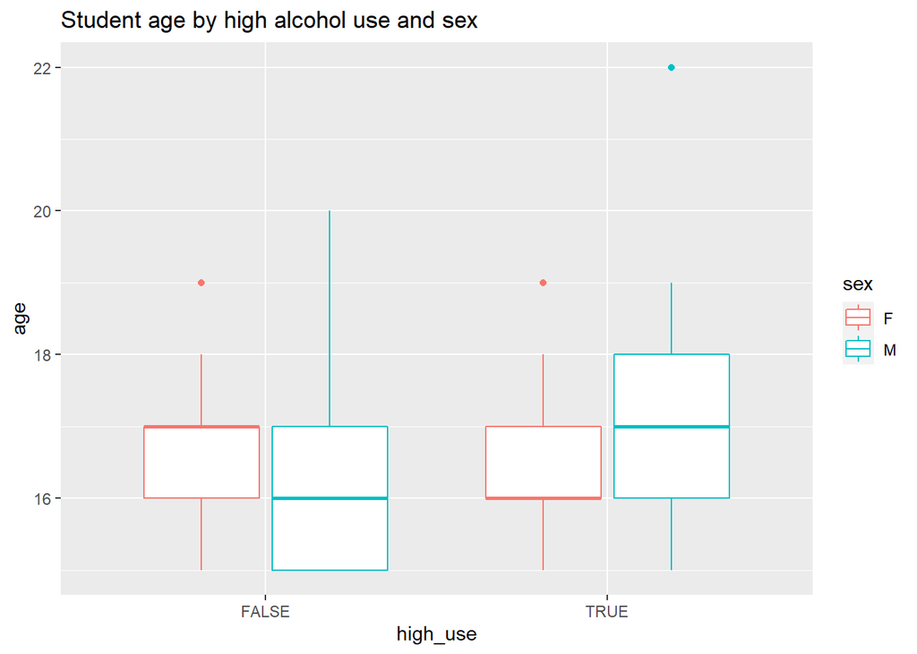

```r
g1 <- ggplot(alc, aes(x = high_use, y = age, col = sex))
g1 + geom_boxplot() + ylab("age") +ggtitle("Student age by high alcohol use and sex")
```

```r
g2 <- ggplot(data = alc, aes(x = age,col=sex))
g2 + geom_bar()
```

[figure not shown]

It can be seen also from this plot that the outliers compose of a couple of persons who are over 18 years-old.

**absences (number of school absences)**

```r
summary(alc$absences)
```

```
##    Min. 1st Qu.  Median    Mean 3rd Qu.    Max.
##   0.000   1.000   3.000   4.511   6.000  45.000
```

```r
g3 <- ggplot(alc, aes(x = high_use, y = absences, col = sex))
g3 + geom_boxplot() + ylab("absences")+ggtitle("Student school absencec by high alcohol use and sex")
```

[figure not shown]

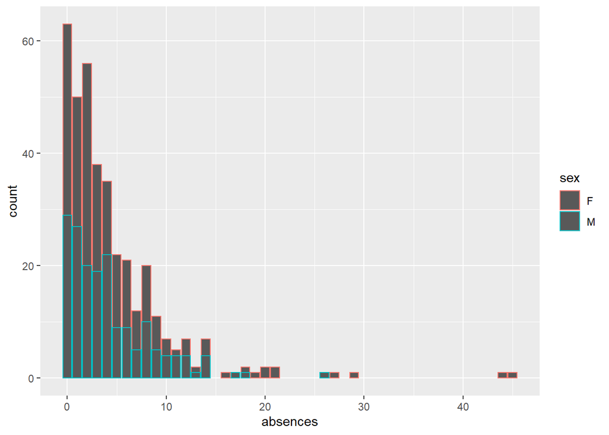

```r
g4 <- ggplot(data = alc, aes(x = absences,col=sex))
g4 + geom_bar()
```

Number of school absences vary between 0-45, mean value is 4.5 as can be seen also from the box plot. Both men and women who use more alcohol have a bit more school absences. Those who have the highest amount of absences are women. I hypothesized that those with high amount of school absences would drink more but I would have waited a clearer difference.

**famrel (quality of family relationships)**

```r
summary(alc$famrel)
```

```
##    Min. 1st Qu.  Median    Mean 3rd Qu.    Max.
##   1.000   4.000   4.000   3.935   5.000   5.000
```

```r
g5 <- ggplot(alc, aes(x = high_use, y = famrel, col = sex))
g5 + geom_boxplot() + ylab("famrel") +ggtitle("Student family relationship by high alcohol use and sex")
```

[figure not shown]

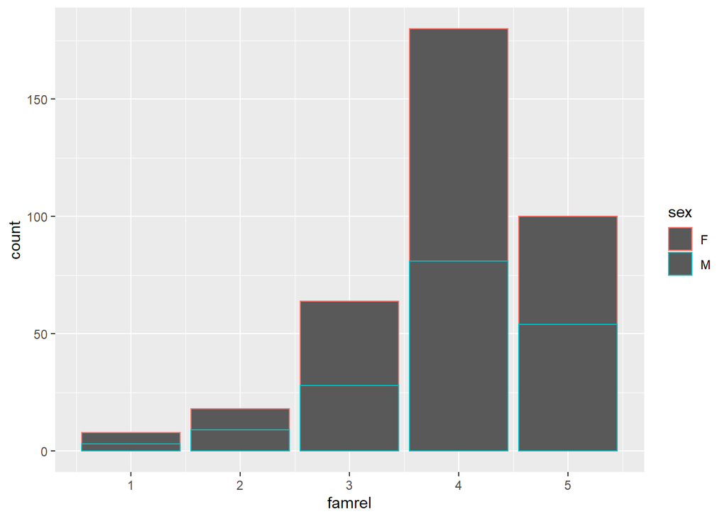

```r
g6 <- ggplot(data = alc, aes(x = famrel,col=sex))
g6 + geom_bar()
```

Quality of family relationships vareis between 1-5, mean value is 3.9. It is quite obvious to see from the box plot that both women and men use more alcohol if they have had lower score in quality of family relationship, so my hypothesis was correct. Mot men and women have somewhat equal score distribution, for example both sexes have had good score (5) in family relationship, not only women or vise verse.

**freetime (free time after school)**

```r
summary(alc$freetime)
```

```
##    Min. 1st Qu.  Median    Mean 3rd Qu.    Max.
##   1.000   3.000   3.000   3.224   4.000   5.000
```

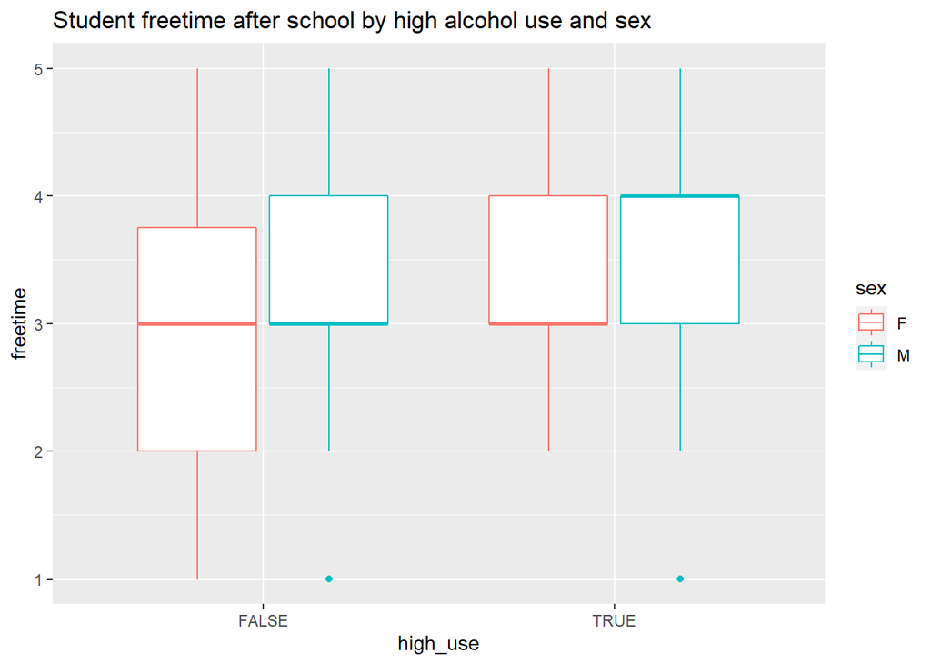

```r
g7 <- ggplot(alc, aes(x = high_use, y = freetime, col = sex))
g7 + geom_boxplot() + ylab("freetime")+ggtitle("Student freetime after school by high alcohol use and sex")
```

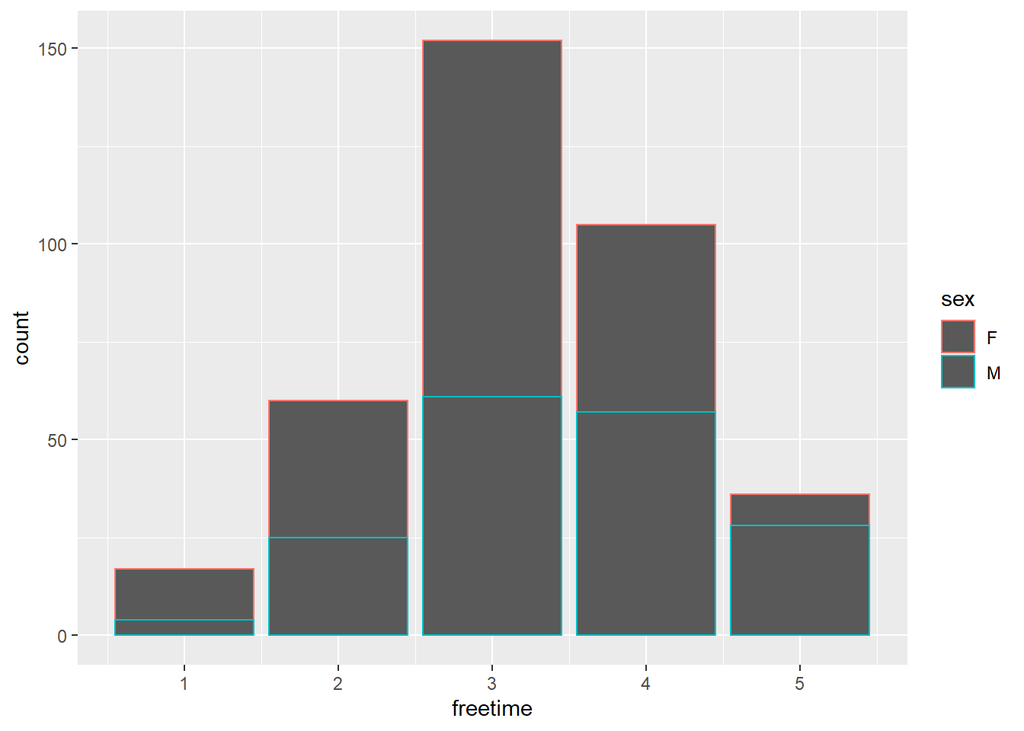

```r
g8 <- ggplot(data = alc, aes(x = freetime,col=sex))
g8 + geom_bar()
```

Students free time after school varies between 1-5 and mean value is 3.2. Women who have more free time use a bit more alcohol than those women who have less free time after school. With men there is no difference. Men seem to have more high scores in freetime, so men have more freetime after school than women. Distribution is quite equal so at this point I am not sure about my hypothesis, because men seem to drink or not drink regardless of their free time.

**Logistic regression**  
I will now do a logistic regression to explore the relationship with the for variables (age, absences, famrel and freetime) with binary high/low alcohol consumption variable (high_use).

```r
model1 <- glm(high_use ~ age + absences + famrel + freetime, data = alc, family = "binomial")
summary(model1)
```

```
##
## Call:
## glm(formula = high_use ~ age + absences + famrel + freetime,
##     family = "binomial", data = alc)
##
## Deviance Residuals:
##     Min       1Q   Median       3Q      Max
## -1.9094  -0.8242  -0.6352   1.1527   2.0206
##
## Coefficients:
##             Estimate Std. Error z value Pr(>|z|)
## (Intercept) -4.19920    1.77086  -2.371 0.017727 *
## age          0.16946    0.10175   1.665 0.095838 .
## absences     0.08331    0.02252   3.699 0.000217 ***
## famrel      -0.35220    0.13071  -2.695 0.007047 **
## freetime     0.45547    0.12770   3.567 0.000362 ***
## ---
## Signif. codes:  0 '***' 0.001 '**' 0.01 '*' 0.05 '.' 0.1 ' ' 1
##
## (Dispersion parameter for binomial family taken to be 1)
##
##     Null deviance: 452.04  on 369  degrees of freedom
## Residual deviance: 413.91  on 365  degrees of freedom
## AIC: 423.91
##
## Number of Fisher Scoring iterations: 4
```

```r
coef(model1) #prints out only the coefficients
```

```
## (Intercept)         age    absences      famrel    freetime
## -4.19919717  0.16946012  0.08330775 -0.35220272  0.45546690
```

Here scale of the coefficients is log(odds). The first intercept is the expected mean value of Y when all X=0. The other intercepts are the slopes. I believe, that for every unit of change in high_use, the log(odds of abcences for example) increases by 0.08. Wald test produces Standard error and z value and finally P-value. All the other explanatory variables other than age are statistically significant (P<0.05) and their ORs and confidence intervals should be significant. Age is not useful predictor for alcohol use and I should drop it. I guess because most of the people were very young, age doesn’t matter.

Deviance measures how closely the model-based fitted values of the response estimates the observed values and it is a measure of fit. The null deviance given is for a model with no explanatory variables, and the residual deviance is that for a model with explanatory variables. The deviance can be used to compare different models.  
AIC=Akaike Information Criterion, is Residual deviance adjusted for the number of parameters in the model. AIC can also me used to compare models to another.

(The following YouTube video help me to interpret the results https://www.youtube.com/watch?v=C4N3_XJJ-jU )

**Odds ratios (OR)**  
I compute Odds ratios (ORs) and confidence intervals (CIs)

```r
OR <- coef(model1) %>% exp
CI <- confint(model1) %>% exp
cbind(OR, CI)
```

```
##                     OR        2.5 %    97.5 %
## (Intercept) 0.01500762 0.0004421303 0.4684254
## age         1.18466510 0.9714868552 1.4495011
## absences    1.08687624 1.0420664951 1.1387728
## famrel      0.70313757 0.5426574324 0.9076387
## freetime    1.57690947 1.2330824203 2.0366156
```

As I assumed due to P-values, the OR for age is not significant because the confidence intervals contain number 1. Otherwise amount of absences and more freetime are associated with increased alcohol use, and good family relationship with decreased alcohol use. My assumptions in the beginning where correct except I had thought that the age would matter but it didn’t.

**Predictive power**

```r
# predict() the probability of high_use
probabilities <- predict(model1, type = "response")
alc <- mutate(alc, probability = probabilities)
# use the probabilities to make a prediction of high_use
alc <- mutate(alc, prediction = probability > 0.5)
# see the last ten original classes, predicted probabilities, and class predictions
select(alc, absences,famrel,freetime,high_use, probability, prediction) %>% tail(10)
```

```
## # A tibble: 10 x 6
##    absences famrel freetime high_use probability prediction
##       <dbl>  <dbl>    <dbl> <lgl>          <dbl> <lgl>
##  1        7      5        4 TRUE           0.376 FALSE
##  2        3      4        3 TRUE           0.281 FALSE
##  3        2      4        4 TRUE           0.361 FALSE
##  4        4      3        2 TRUE           0.277 FALSE
##  5        3      3        3 FALSE          0.357 FALSE
##  6        4      4        3 TRUE           0.298 FALSE
##  7        0      4        2 FALSE          0.162 FALSE
##  8        4      4        4 TRUE           0.442 FALSE
##  9        8      5        4 TRUE           0.437 FALSE
## 10        0      4        3 FALSE          0.265 FALSE
```

```r
# tabulate the target variable versus the predictions
table(high_use = alc$high_use, prediction = alc$prediction)
```

```
##         prediction
## high_use FALSE TRUE
##    FALSE   240   19
##    TRUE     92   19
```

```r
summary(alc$high_use)
```

```
##    Mode   FALSE    TRUE
## logical     259     111
```

I am not sure how to interpret the 2x2 cross tabulation, but I guess that there were in total 240+19=259 persons who did not use very much alcohol and 92+19=111 persons who used a lot of alcohol. Of those 259 persons who were FALSE, the model predicted to be TRUE, so not all were correct. And for some reason for those 111 persons who drank a lot, 92 were predicted to actually to be in FALSE category meaning they don’t drink a lot. So the model does not predict very well persons who use lot of alcohol(?).

**Let’s plot more**

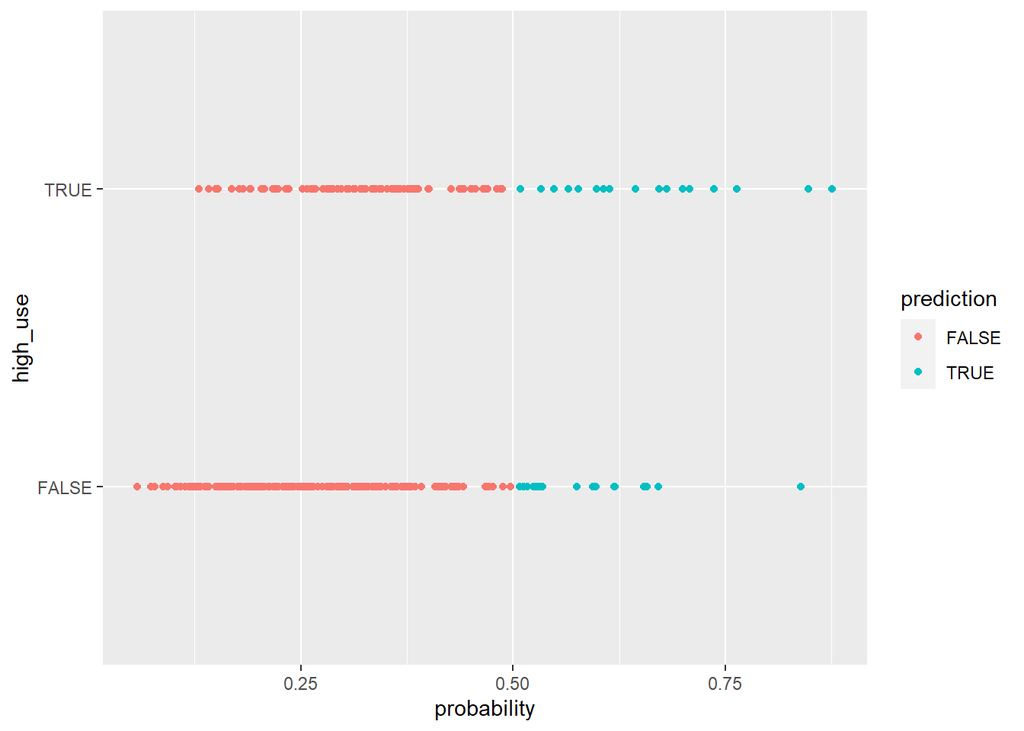

```r
# initialize a plot of 'high_use' versus 'probability' in 'alc'
g <- ggplot(alc, aes(x = probability, y = high_use, col = prediction))
g + geom_point()
```

```r
table(high_use = alc$high_use, prediction = alc$prediction) %>% prop.table %>% addmargins
```

```
##         prediction
## high_use      FALSE       TRUE        Sum
##    FALSE 0.64864865 0.05135135 0.70000000
##    TRUE  0.24864865 0.05135135 0.30000000
##    Sum   0.89729730 0.10270270 1.00000000
```

**Computing the average number of incorrect predictions**

```r
# define a loss function (average prediction error)
loss_func <- function(class, prob) {
  n_wrong <- abs(class - prob) > 0.5
  mean(n_wrong)
}
# the average number of wrong predictions in the alc data
loss_func(class = alc$high_use, prob = 0)
```

```
## [1] 0.3
```

```r
loss_func(class = alc$high_use, prob = 1)
```

```
## [1] 0.7
```

```r
loss_func(class = alc$high_use, prob = alc$probability)
```

```
## [1] 0.3
```

I am not sure how to interpret this either… but this gives me the same numbers: If the probability is 0, then high_use is 0 for all (meaning low alcohol use) and then average percentage of wrong predictions is 30% (?) Probability 1 means that high_use is 1 i.e. high alcohol use for all and then average percentage of wrong predictions is 70%(?). Perhaps the probability here refers to the penalty, here it is 30%.

I will try to do the cross-validation:

```r
# define a loss function (average prediction error)
loss_func <- function(class, prob) {
  n_wrong <- abs(class - prob) > 0.5
  mean(n_wrong)
}

# compute the average number of wrong predictions in the (training) data
loss_func(class = alc$high_use, prob = alc$probability)
```

```
## [1] 0.3
```

```r
# K-fold cross-validation
library(boot)
cv <- cv.glm(data = alc, cost = loss_func, glmfit = model1, K = 10)

# average number of wrong predictions in the cross validation
cv$delta[1]
```

```
## [1] 0.3054054
```

I guess the error here is 0.3 so it is more than the model that was introduced in DataCamp.

**Learning diary**

So far, I have learned a lot how RStudio works and how you have to handle the data to get some results.  
It has surprised me that R uses different kind of packages to work.  
It would be very helpful if we would first get a real lecture how to interpret the results. DataCamp in not helpful enough and neither is the Kimmo’s book (although it is a good book :) ). Now with the time I have, I just do my best to finish the exercises somehow but what would really like to learn is to interpret the results, not just how thing are done mechanically. But anyway, I still have learned new thing about logistic regression, so I am looking forward what to learn next.